# EU-ForDAM: gap-filling test and gap-filled dataset (v1)

PhD objective 1: harmonising incomplete records

Published

October 22, 2026

## The question

Most gaps in EU-ForDAM are insects a country never reported. Following the thesis premise, *the existing records carry information about the missing ones*, we estimate those gaps from the insects that **were** reported. Rules: 0 = monitored, no damage (kept); not reported = unknown (estimated, never set to 0); host tree absent from the region = 0 (forest table of Hlasny et al. 2025); value1 only; the Czech spruce bark-borer group counted as *I. typographus* as in the paper.

## How methods were tested

Real reported values were **hidden** in whole country x insect blocks (exactly the shape of a real gap: a country without any record of an insect), predicted from the rest, and compared with the truth: 17,351 hidden cells, 10 rounds. Insects reported by only one country cannot be tested this way.

| Method | What it does |
| --- | --- |
| Simple average | the insect’s mean in that year (the yardstick) |
| Partner method | borrows from insects linked to it (correlation metrics) recorded in the same region-year |
| Factor model | latent factor model using all insects at once, in two parts: *any damage?* x *how much?*; each insect’s level pulled towards its broad group |
| + forest area | the factor model plus host-forest area per region (NUTS forest table) |

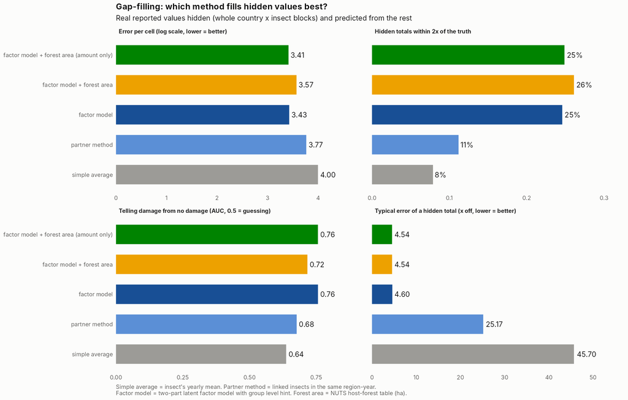

| method | error per cell (log) | damage vs no damage (AUC) | totals within 2x | typical total error (x off) |
| --- | --- | --- | --- | --- |
| simple average | 4.00 | 0.64 | 8% | 45.70 |
| partner method | 3.77 | 0.68 | 11% | 25.17 |
| factor model | 3.43 | 0.76 | 25% | 4.60 |
| factor model + forest area | 3.57 | 0.72 | 26% | 4.54 |
| factor model + forest area (amount only) | 3.41 | 0.76 | 25% | 4.54 |

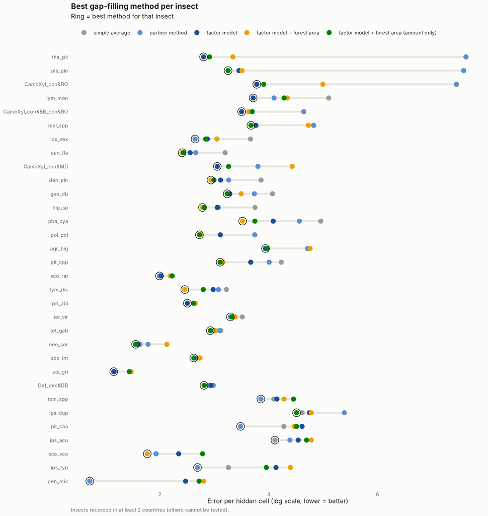

The best method differs by insect; the partner method wins for several conifer bark beetles with strong, consistent partners.

## Attempts to improve further

| method | error per cell (log) | damage vs no damage (AUC) | totals within 2x | typical total error (x off) |
| --- | --- | --- | --- | --- |
| factor model (v1) | 3.39 | 0.76 | 25% | 4.54 |
| recalibrated only | 3.42 | 0.74 | 8% | 26.96 |
| + memory | 3.42 | 0.75 | 8% | 26.63 |
| + neighbours | 3.37 | 0.74 | 7% | 34.91 |
| + reporting effect | 3.44 | 0.74 | 8% | 26.21 |
| + all three | 3.39 | 0.75 | 7% | 31.10 |
| + all three, Tweedie | 5.06 | 0.73 | 22% | 6.03 |

Memory (the region’s other insects last year), neighbouring regions (NUTS positions), a country reporting effect and a Tweedie distribution were added as a second stage. None beat the factor model: memory and reporting level are already captured by it through the other insects; neighbours carry a little extra information, but adding them as a second stage disturbs the level and damages totals. This suggests the model is close to what the damage records alone can predict; further gains likely need external drivers (drought/VPD, storms) and spatial structure inside the model.

## The gap-filled dataset (v1)

Method: factor model + forest area for amounts; partner method for the insects where it tested best.

| value_type | cells | share |
| --- | --- | --- |
| filled | 40589 | 47% |
| reported zero | 17254 | 20% |
| not fillable (nothing recorded in this region-year) | 13463 | 16% |
| reported damage | 9828 | 11% |
| zero: host tree absent | 5645 | 7% |

| confidence | filled cells | insects |
| --- | --- | --- |
| reliable | 9836 | 14 |
| untested | 17476 | 17 |
| weak | 13277 | 18 |

**Confidence** of a filled value: *reliable* = in the test, its method beats the simple average for that insect and separates damage from no damage (AUC >= 0.7); *weak* = tested but not both; *untested* = insect reported by one country only.

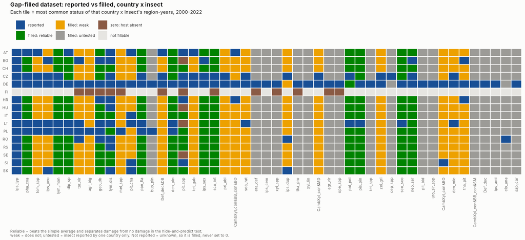

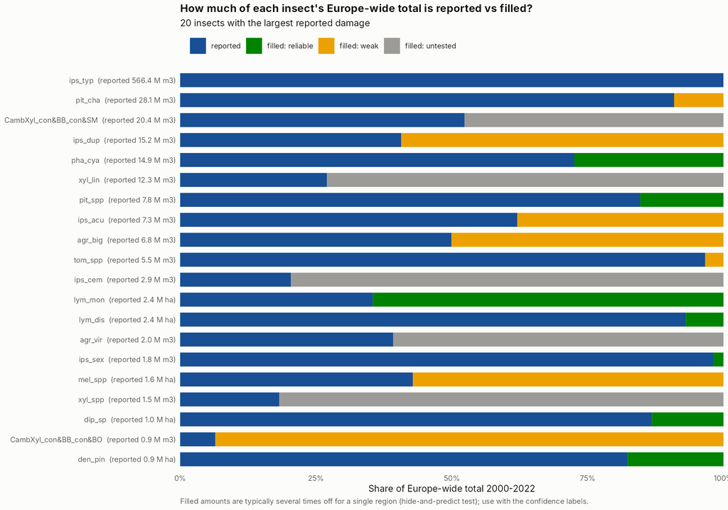

| insect | unit | reported (M) | + reliable fill (M) | + weak fill (M) | + untested fill (M) |
| --- | --- | --- | --- | --- | --- |
| ips_typ | m3 | 566.39 | 0.00 | 0.08 | 0.00 |
| pit_cha | m3 | 28.15 | 0.00 | 2.81 | 0.00 |
| CambXyl_con&BB_con&SM | m3 | 20.36 | 0.00 | 0.00 | 18.55 |
| ips_dup | m3 | 15.25 | 0.00 | 22.24 | 0.00 |
| pha_cya | m3 | 14.90 | 5.63 | 0.00 | 0.00 |
| xyl_lin | m3 | 12.31 | 0.00 | 0.00 | 33.25 |
| pit_spp | m3 | 7.85 | 1.42 | 0.00 | 0.00 |
| ips_acu | m3 | 7.28 | 0.00 | 4.45 | 0.00 |
| agr_big | m3 | 6.80 | 0.00 | 6.82 | 0.00 |
| tom_spp | m3 | 5.45 | 0.00 | 0.19 | 0.00 |
| ips_cem | m3 | 2.89 | 0.00 | 0.00 | 11.30 |
| lym_mon | ha | 2.44 | 4.43 | 0.00 | 0.00 |

## The gap-filled dataset v2 (factor model only, with ranges)

Changes from v1: the same data as the correlation metrics (Czech spruce bark-borer group counted as *I. typographus*); the factor model only (no partner method); aggregate reporting codes are not filled; every filled total has an 80% range taken from the hide-and-predict test.

| value_type | confidence | cells | share |
| --- | --- | --- | --- |
| filled | reliable | 6083 | 7% |
| filled | untested | 14552 | 17% |
| filled | weak | 14150 | 17% |
| not fillable (nothing recorded in this region-year) | NA | 11898 | 14% |
| not filled: aggregate reporting code | NA | 5943 | 7% |
| reported damage | NA | 9814 | 12% |
| reported zero | NA | 16923 | 20% |
| zero: host tree absent | NA | 5645 | 7% |

**Ranges.** The final model was re-run 10 times, each time with different country x insect blocks hidden. For every hidden country x insect x year total the real value is known, so the spread of *real / predicted* tells how far off a filled total typically is; its 10% and 90% points give the 80% range (per insect when it has at least 30 hidden totals). Check: learning the spread on half the folds, 74% of the other half’s real totals fall inside the 80% range (target 80%), so the ranges are slightly too narrow.

**Confidence.** *Reliable* = in the test, the model beats the simple average for that insect and separates damage from no damage (AUC >= 0.7): 9 insects (den_pin, dip_sp, lym_dis, neo_ser, pan_fla, pha_cya, pis_pin, pit_spp, pol_pol). *Weak* = tested but not both: 20 insects. *Untested* = recorded in one country only; filled but left out of totals.

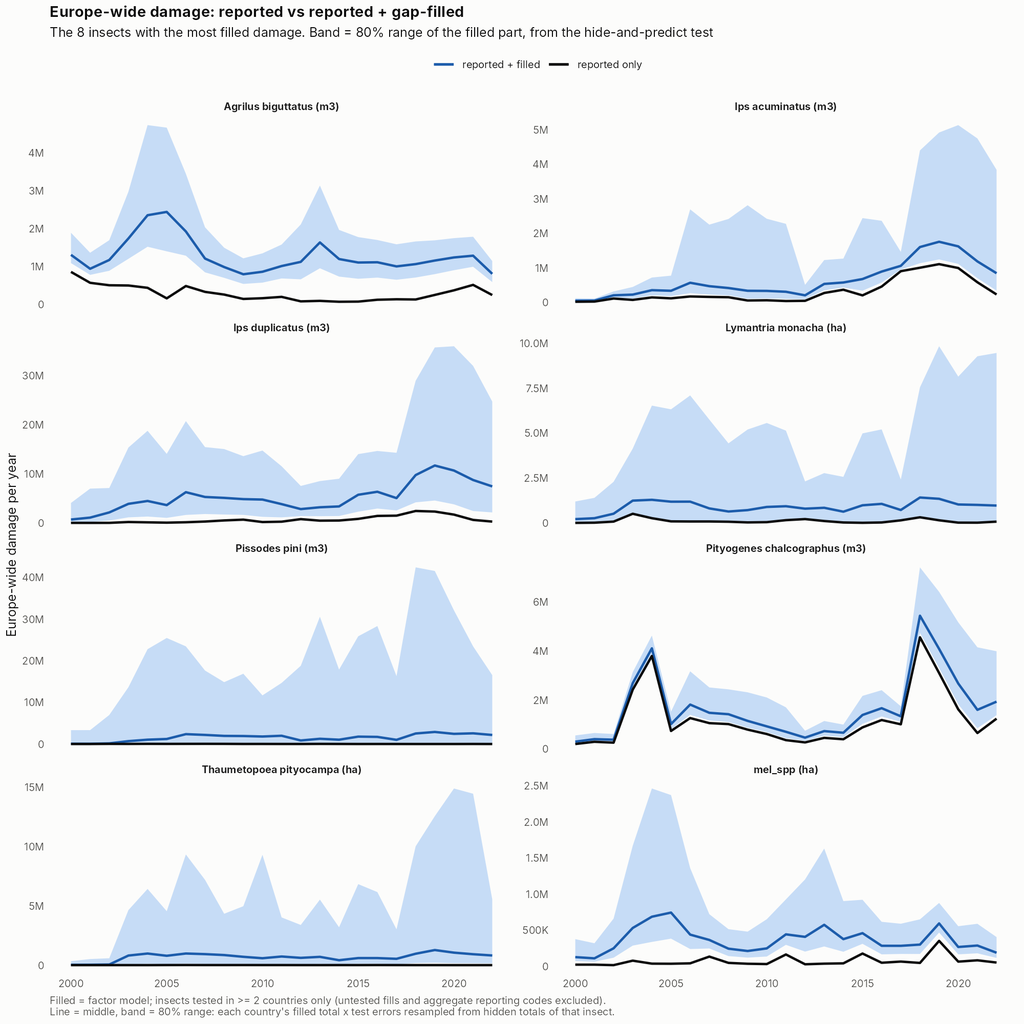

**Caution.** For several insects the filled damage is many times the reported damage (e.g. *Ips duplicatus*, *Pissodes pini*, *Thaumetopoea pityocampa*, *Lymantria monacha*). The model fills every region where the host tree grows and something was recorded, including countries outside an insect’s geographic range (the pine processionary moth is Mediterranean). A country x insect “could occur here” mask (range maps or expert judgement) is needed before Europe-wide totals are used.

## The gap-filled dataset v3 (current): better model + draft range rule

**Retooled on the 2025 paper’s hierarchy.** Aggregate reporting codes (several insects lumped together) are model input only: they help the model learn the region-year patterns but are never filled, and all test scores below are on single insects. The spruce bark-borer group of CZ and DE is counted as *I. typographus*, and `tha_pit` is *T. pityocampa* (filled only in BG, CH, HR, IT, SI), both as in the paper. Totals are reported per paper group, with the aggregates added into the reported part:

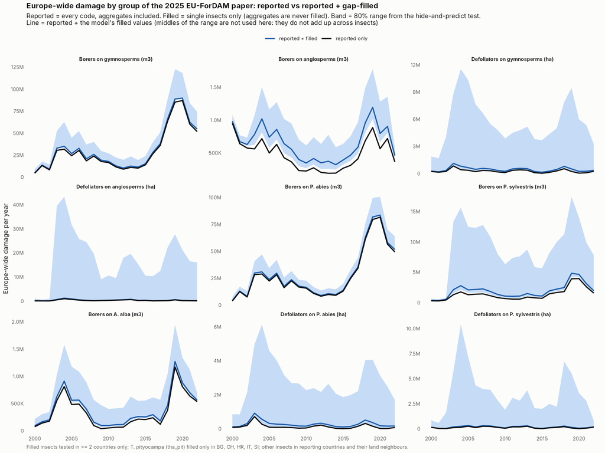

| level | group | unit | reported | filled | filled vs reported |
| --- | --- | --- | --- | --- | --- |
| level1 | Borers on angiosperms | m3 | 10,869,383 | 3,963,186 | 36% |
| level1 | Borers on gymnosperms | m3 | 686,541,052 | 42,896,195 | 6% |
| level1 | Defoliators on angiosperms | ha | 6,629,198 | 1,993,805 | 30% |
| level1 | Defoliators on gymnosperms | ha | 5,832,112 | 4,218,448 | 72% |
| level2 | Borers on A. alba | m3 | 7,849,192 | 1,346,971 | 17% |
| level2 | Borers on P. abies | m3 | 643,611,145 | 27,205,983 | 4% |
| level2 | Borers on P. sylvestris | m3 | 31,543,921 | 12,639,728 | 40% |
| level2 | Defoliators on P. abies | ha | 2,952,689 | 3,234,583 | 110% |
| level2 | Defoliators on P. sylvestris | ha | 2,879,423 | 983,864 | 34% |

**Better model (M2).** Six versions of the factor model were compared in the same hide-and-predict test. The chosen one (M2) separates each region-year’s overall intensity into region and year parts and uses 3 hidden factors whose insect sensitivities are pulled towards the insect’s broad group.

| model | error (log) | AUC | totals within 2x | typical total off (x) | usable pairs the model links |
| --- | --- | --- | --- | --- | --- |
| M0 current | 3.37 | 0.78 | 25% | 4.64 | 13 of 28 |
| M1 region+year (pull 5) | 3.37 | 0.79 | 27% | 4.48 | 14 of 28 |
| M1 region+year (pull 20) | 3.37 | 0.78 | 27% | 4.56 | 16 of 28 |
| M2 K=3 + group links | 3.34 | 0.79 | 27% | 4.35 | 22 of 28 |
| M2 K=4 + group links | 3.34 | 0.79 | 27% | 4.35 | 22 of 28 |
| M2 K=4, no group links | 3.36 | 0.79 | 26% | 4.64 | 13 of 28 |

M2 is slightly better at filling (AUC 0.78 to 0.79, typical total error 4.64x to 4.35x) and reproduces far more of the usable insect pairs from the correlation metrics (22 of 28 instead of 13). It was picked out of six versions on the same test, so its lead is slightly optimistic.

**Draft range rule.** An insect is filled only in countries that report damage from it or share a border with one that does; elsewhere the cell is 0 (“outside range”). This is a data-only stand-in for an expert range table (`outputs/tables/GF2_range_draft_for_correction.xlsx`). `tha_pit` is *Thaumetopoea pityocampa* (as in the paper) and is allowed only in BG, CH, HR, IT and SI.

| value_type | confidence | cells | share |
| --- | --- | --- | --- |
| filled | reliable | 5949 | 7% |
| filled | untested | 9443 | 11% |
| filled | weak | 6902 | 8% |
| not fillable (nothing recorded in this region-year) | NA | 11898 | 14% |
| not filled: aggregate reporting code | NA | 5943 | 7% |
| reported damage | NA | 9814 | 12% |
| reported zero | NA | 16923 | 20% |
| zero: host tree absent | NA | 5645 | 7% |
| zero: outside range (draft rule) | NA | 12491 | 15% |

Ranges: 74% of hidden real totals fall inside the 80% range (target 80%). Reliable insects: 15; weak: 14.

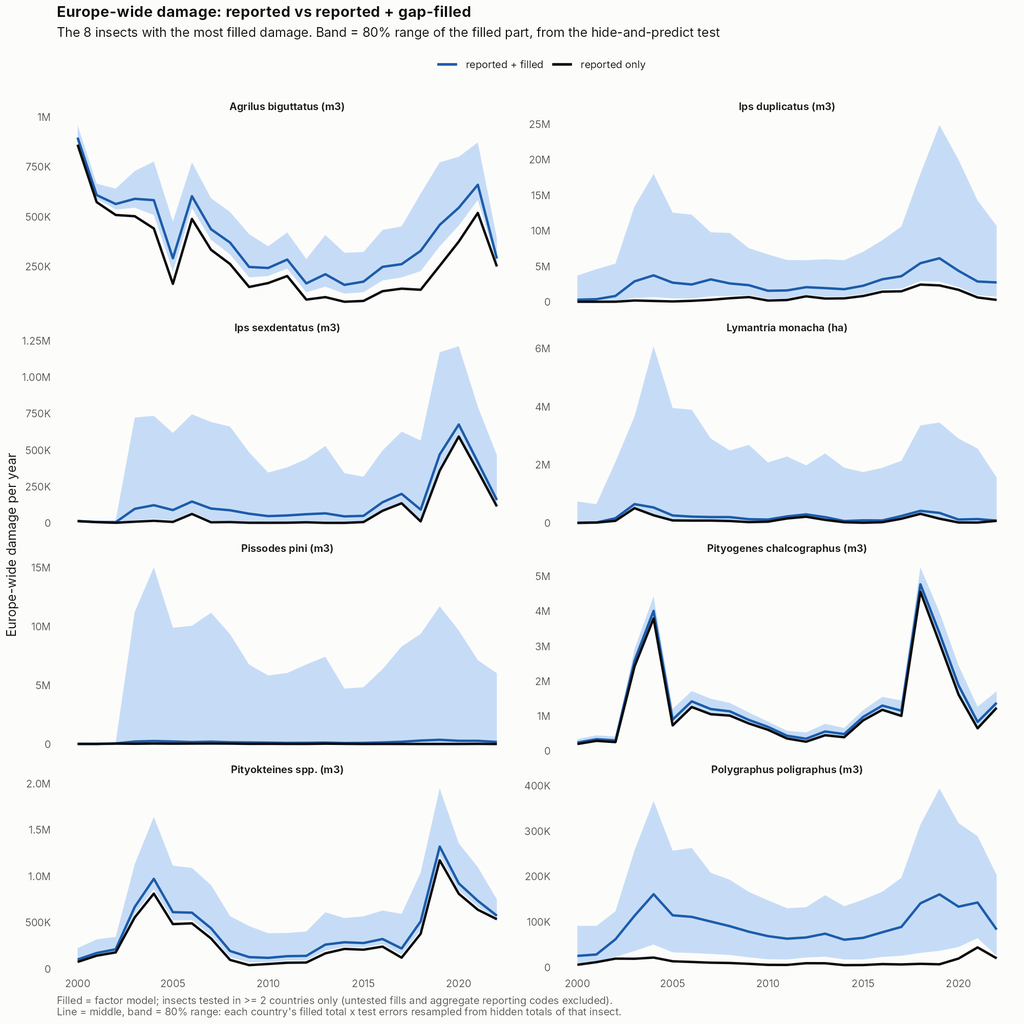

With the range rule, for most insects the filled part is 0.1-1x the reported damage. Still implausibly high and needing expert range checks: *Pissodes pini* (9x reported), *Polygraphus poligraphus* (7x), *Ips duplicatus* (3x).

## The gap-filled dataset v4: v3 rebuilt on the shared host table

Same model (M2) and range rule as v3. What changed is the host information each insect gets: it is now the same host table used for the host-share, totals and correlation work. For example, *L. monacha* is “spruce and pine” (all conifers), *Melolontha* is “all forest”, *Zeiraphera* is “larch”, and *L. dispar* and *A. viridis* are “broadleaves”. Recorded damage on a tree shows that the wider forest column is there too (spruce, pine, fir → conifers; oak → broadleaves).

| model | error (log) | AUC | totals within 2x | typical total off (x) | usable pairs linked |
| --- | --- | --- | --- | --- | --- |
| v3 (M2, old host labels) | 3.34 | 0.79 | 27% | 4.35 | 22 of 28 |
| v4 (M2, shared host table) | 3.31 | 0.80 | 29% | 4.21 | 22 of 28 |

| group | unit | reported | filled | filled vs reported |
| --- | --- | --- | --- | --- |
| Borers on angiosperms | m3 | 10,869,383 | 2,940,245 | 27% |
| Borers on gymnosperms | m3 | 686,541,052 | 36,130,438 | 5% |
| Defoliators on angiosperms | ha | 6,629,198 | 2,606,910 | 39% |
| Defoliators on gymnosperms | ha | 5,832,112 | 1,803,938 | 31% |

- **Test scores:** slightly better on every measure. This was not tuned on the test, so it is a fair gain.
- **Generalists** (*L. dispar*, *Melolontha*, *Geometridae*, …) are no longer set to 0 in the 19 regions without oak.
- *L. monacha*: filled damage falls from 2.7 to 0.4 million ha. v3 scaled it by spruce area: Poland has little spruce, so the rate per spruce hectare was huge, and Austria got 1.5 million ha. It is now scaled by all conifers.
- **Check:** no filled region-year is above 10% of its host (the highest is 9.5%). Reported values go up to 67%, so the fills are typical years and never outbreaks.
- **Still implausible:** *Zeiraphera griseana* (larch bud moth), with 616,000 ha filled from 958 ha reported, 446,000 ha of it in Poland. Larch has no column in the forest appendix, and scaling by all conifers gives Poland’s pine forests to a larch insect. Also insects reported by only 2–3 countries and filled into AT, CH, PL and SK: *S. ratzeburgi*, *S. scolytus*, *Neodiprion*, *Polygraphus*, *P. pini* (9–22x reported).

## v4b (current) and v5: hosts without their own forest data

Two ways to stop larch, birch, elm and poplar insects being scaled by a stand-in area (all conifers / all broadleaves):

- **v4b:** v4, but these insects get the model’s plain (unscaled) amount.
- **v5:** the 2025 paper’s approach. Nothing is scaled; log(host area) is a model input, and the model learns for each insect how strongly damage rises with it.

| model | error (log) | AUC | totals within 2x | typical total off (x) | usable pairs linked |
| --- | --- | --- | --- | --- | --- |
| v4 (M2, shared host table) | 3.31 | 0.80 | 29% | 4.21 | 22 of 28 |
| v4b (no stand-in host areas) | 3.31 | 0.80 | 29% | 4.15 | 21 of 28 |
| v5 (host area as a model input) | 3.35 | 0.79 | 18% | 8.22 | 21 of 28 |

| version | filled cells | highest share of host | above 100% of host |
| --- | --- | --- | --- |
| v4b | 21738 | 10% | 0 |
| v5 | 21738 | 2481% | 138 |

## Current totals: reported + reliable fills only

The totals now follow the rule below: only fills from **reliable** insects are added. Reliable means that in the hide-and-predict test the model beats the simple average for that insect and separates damage from no damage (AUC ≥ 0.7). Weak and untested fills stay in the dataset with their labels, but are listed separately and never added. Model: v4b, with the range list applied.

| group | unit | reported | + reliable fills | reliable vs reported | weak fills (not added) |
| --- | --- | --- | --- | --- | --- |
| Borers on angiosperms | m3 | 10,869,383 | 1,212,318 | 11% | 1,338,689 |
| Borers on gymnosperms | m3 | 686,541,052 | 13,774,206 | 2% | 22,212,731 |
| Defoliators on angiosperms | ha | 6,629,198 | 2,023,220 | 30% | 840,730 |
| Defoliators on gymnosperms | ha | 5,832,112 | 1,082,938 | 19% | 411,262 |

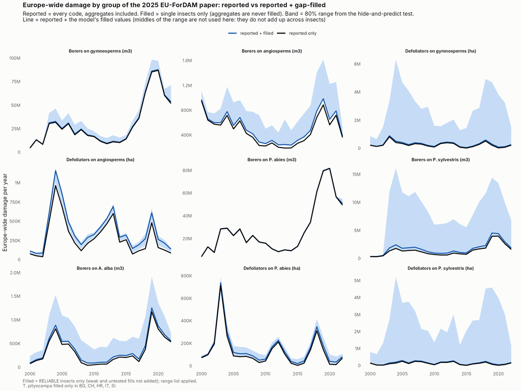

- Gap-filling adds 2% to borers on gymnosperms, 11% to borers on angiosperms, 31% to defoliators on angiosperms and 19% to defoliators on gymnosperms.
- *D. micans* (1.7 million m³), *I. duplicatus* (12 million m³) and *Zeiraphera* (155,000 ha) are weak, so they are no longer in the totals.
- Some reliable insects are still filled at many times what is reported: *Polygraphus* (12x), *Neodiprion* (11x), *P. pini* (9x). They pass the test, but their fills sit mostly in countries that never report them, so the range list decides whether they stay.
- Per-insect table: `outputs/tables/GF_CURRENT_totals_by_insect.csv`.

## How to read it

- Reported values are untouched; every filled value carries its method and confidence.
- Filled values are good for **whether and when** damage occurred, rough for **how much** (a single regional total is typically several times off).
- Europe-wide totals: use reported + reliable fills; treat weak and untested fills as indications only.